# 1US0 TYR Ring_0_0.3_12_Density

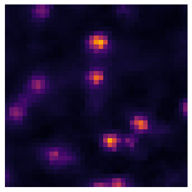

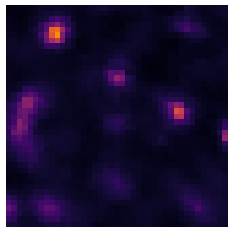

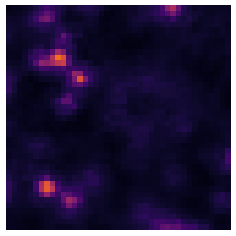

18/41

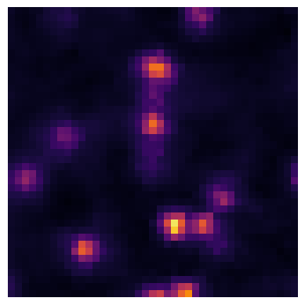

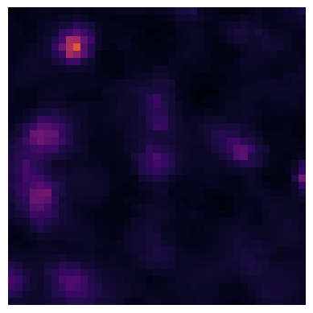

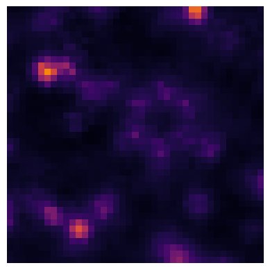

19/41

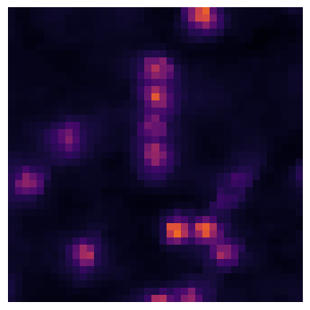

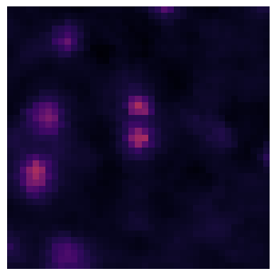

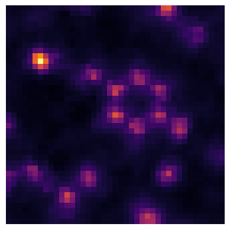

20/41

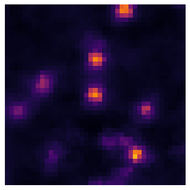

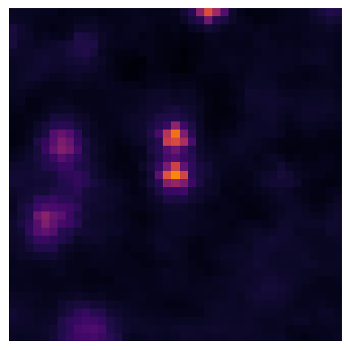

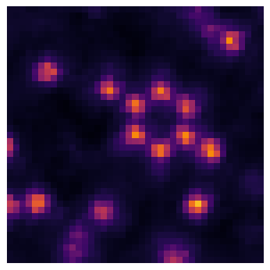

21/41

21/41

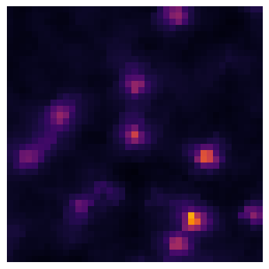

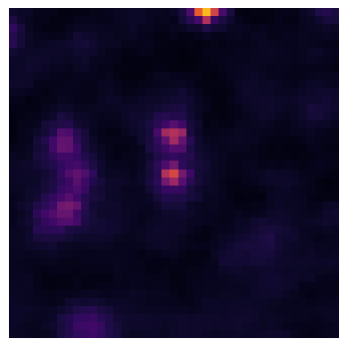

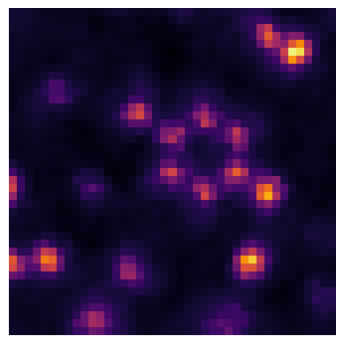

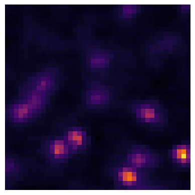

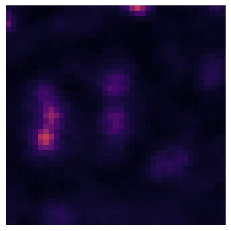

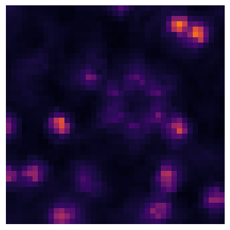

23/41

23/41

23/41

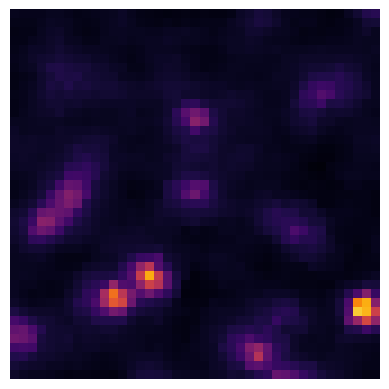

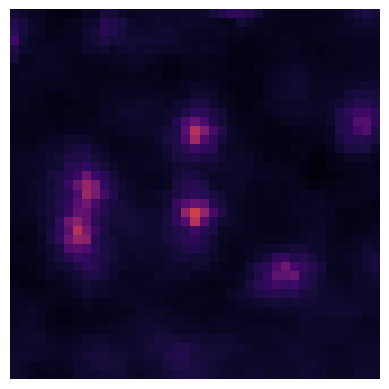

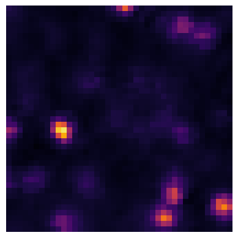

24/41

24/41

24/41

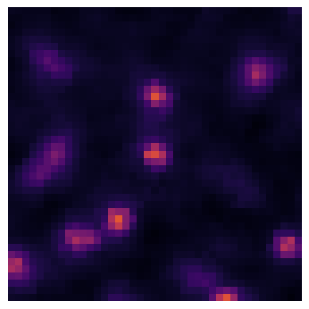

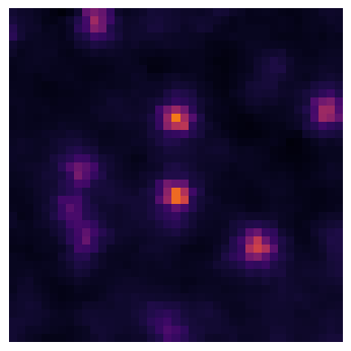

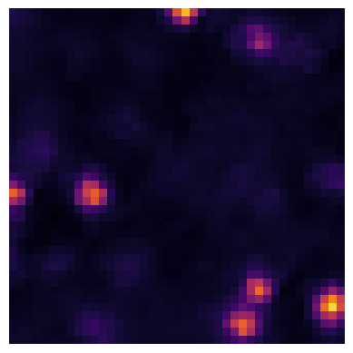

25/41

25/41

25/41

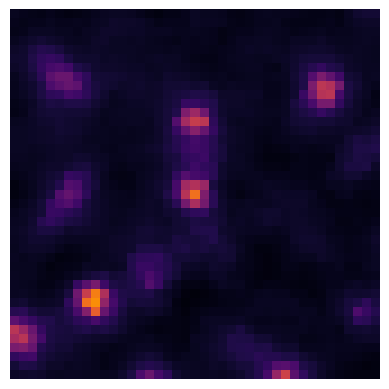

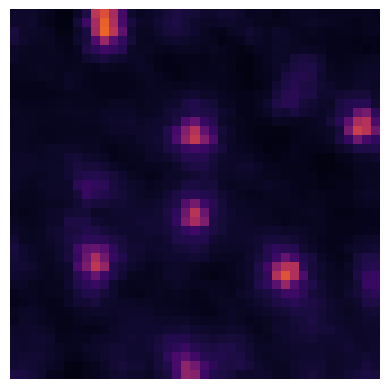

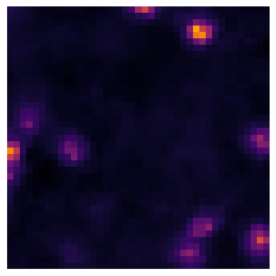

26/41

26/41

26/41

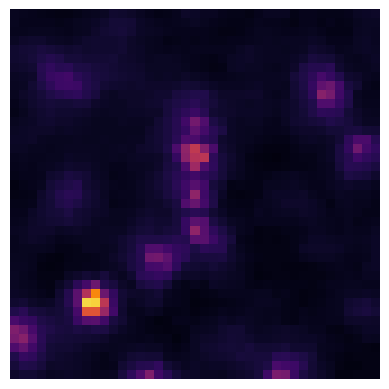

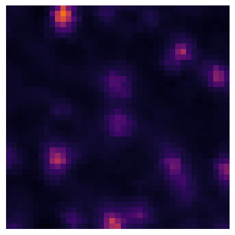

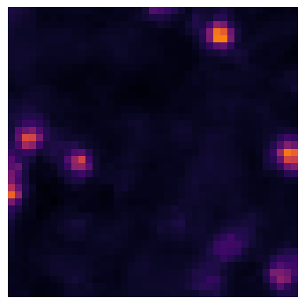

27/41

27/41

27/41

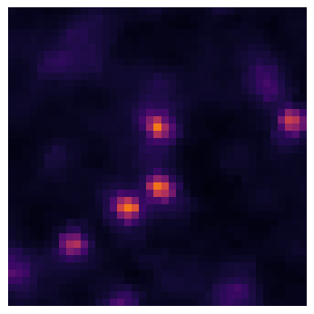

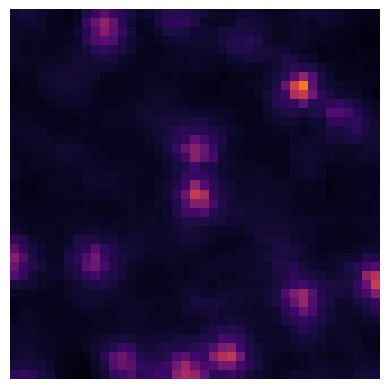

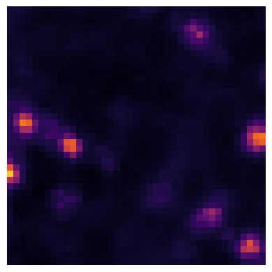

28/41

28/41

28/41

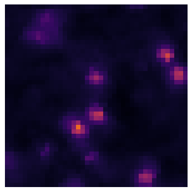

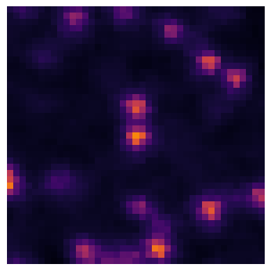

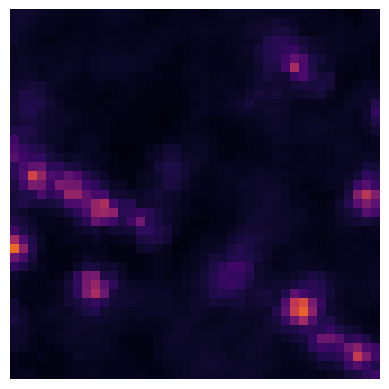

29/41

29/41

29/41

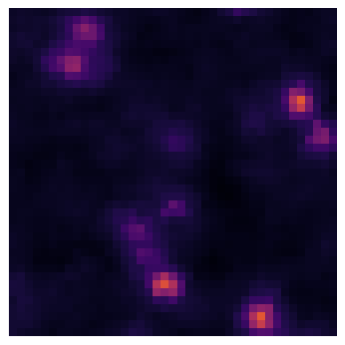

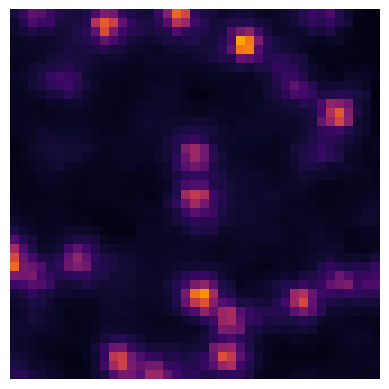

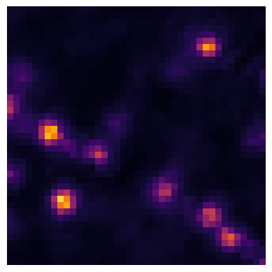

30/41

30/41

30/41

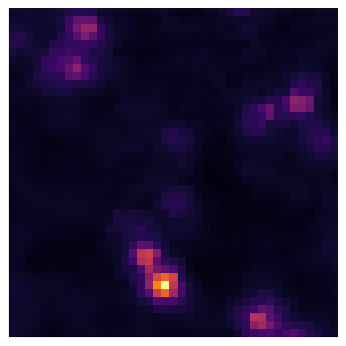

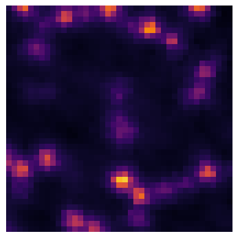

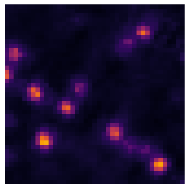

31/41

31/41

31/41

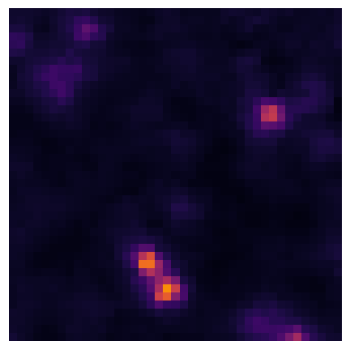

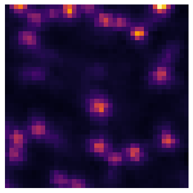

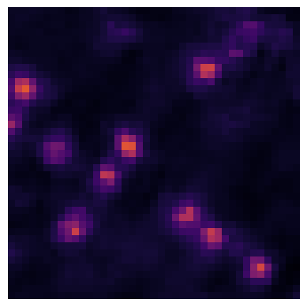

32/41

32/41

32/41

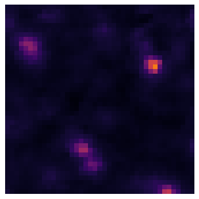

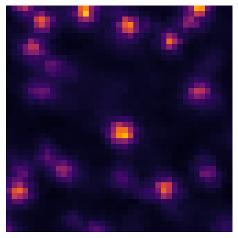

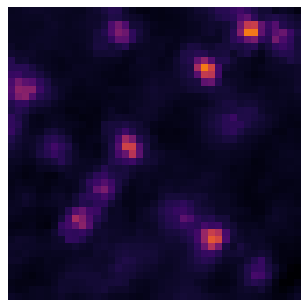

33/41

33/41